# R for Data Science Solution Set

# Preface

This is a solution guide to the exercises in [R for Data Science](http://r4ds.had.co.nz/index.html) by Hadley Wickham and Garret Grolemund.

This guide is a work in progress, and all are welcome to contribute. The complete source for this book is available on [github](https://github.com/khueyama/r4ds-exercises); full instructions on how to contribute are available in the README.

# Chapter 3 - Data Visualisation

## 3.2 - First Steps

### Problem 1

### Problem 2

## [1] 234

## [1] 11

### Problem 3

### Problem 4

### Problem 5

## 3.3 - Aesthetic Mappings

### Problem 1

### Problem 2

## Classes ‘tbl_df’, ‘tbl’ and ‘data.frame’: 234 obs. of 11 variables:

## $ manufacturer: chr “audi” “audi” “audi” “audi” …

## $ model : chr “a4” “a4” “a4” “a4” …

## $ displ : num 1.8 1.8 2 2 2.8 2.8 3.1 1.8 1.8 2 …

## $ year : int 1999 1999 2008 2008 1999 1999 2008 1999 1999 2008 …

## $ cyl : int 4 4 4 4 6 6 6 4 4 4 …

## $ trans : chr “auto(l5)” “manual(m5)” “manual(m6)” “auto(av)” …

## $ drv : chr “f” “f” “f” “f” …

## $ cty : int 18 21 20 21 16 18 18 18 16 20 …

## $ hwy : int 29 29 31 30 26 26 27 26 25 28 …

## $ fl : chr “p” “p” “p” “p” …

## $ class : chr “compact” “compact” “compact” “compact” …

### Problem 3

### Problem 4

### Problem 5

### Problem 6

## 3.5 - Facets

### Problem 1

### Problem 2

### Problem 3

### Problem 4

### Problem 5

### Problem 6

## 3.6 - Geometric Objects

### Problem 1

## `stat_bin()` using `bins = 30`. Pick better value with `binwidth`.

### Problem 2

## `geom_smooth()` using method = ‘loess’

### Problem 3

## `geom_smooth()` using method = ‘loess’

## `geom_smooth()` using method = ‘loess’

### Problem 4

## `geom_smooth()` using method = ‘loess’

## `geom_smooth()` using method = ‘loess’

### Problem 5

## `geom_smooth()` using method = ‘loess’

## `geom_smooth()` using method = ‘loess’

### Problem 6

## `geom_smooth()` using method = ‘loess’

## `geom_smooth()` using method = ‘loess’

## `geom_smooth()` using method = ‘loess’

## `geom_smooth()` using method = ‘loess’

## `geom_smooth()` using method = ‘loess’

## 3.7 - Statistical Transformations

### Problem 1

### Problem 2

### Problem 3

### Problem 4

### Problem 5

## 3.8 - Position Adjustments

### Problem 1

### Problem 2

### Problem 3

### Problem 4

## 3.9 - Coordinate Systems

### Problem 1

### Problem 2

### Problem 3

### Problem 4

# Chapter 5 - Data Transformation

## 5.2 - Filter Rows with filter()

### Problem 1

## # A tibble: 1 x 1

## n

## 1 10200

## # A tibble: 1 x 1

## n

## 1 9313

## # A tibble: 1 x 1

## n

## 1 139504

## # A tibble: 1 x 1

## n

## 1 86326

## # A tibble: 1 x 1

## n

## 1 29

## # A tibble: 1 x 1

## n

## 1 2074

## # A tibble: 1 x 1

## n

## 1 9344

### Problem 2

## # A tibble: 1 x 1

## n

## 1 9344

### Problem 3

## # A tibble: 1 x 1

## n

## 1 8255

## year month day dep_time

## Min. :2013 Min. : 1.000 Min. : 1.0 Min. : NA

## 1st Qu.:2013 1st Qu.: 3.000 1st Qu.: 8.0 1st Qu.: NA

## Median :2013 Median : 6.000 Median :12.0 Median : NA

## Mean :2013 Mean : 5.927 Mean :14.6 Mean :NaN

## 3rd Qu.:2013 3rd Qu.: 8.000 3rd Qu.:23.0 3rd Qu.: NA

## Max. :2013 Max. :12.000 Max. :31.0 Max. : NA

## NA’s :8255

## sched_dep_time dep_delay arr_time sched_arr_time

## Min. : 106 Min. : NA Min. : NA Min. : 1

## 1st Qu.:1159 1st Qu.: NA 1st Qu.: NA 1st Qu.:1330

## Median :1559 Median : NA Median : NA Median :1749

## Mean :1492 Mean :NaN Mean :NaN Mean :1669

## 3rd Qu.:1855 3rd Qu.: NA 3rd Qu.: NA 3rd Qu.:2049

## Max. :2359 Max. : NA Max. : NA Max. :2359

## NA’s :8255 NA’s :8255

## arr_delay carrier flight tailnum

## Min. : NA Length:8255 Min. : 1 Length:8255

## 1st Qu.: NA Class :character 1st Qu.:1577 Class :character

## Median : NA Mode :character Median :3535 Mode :character

## Mean :NaN Mean :3063

## 3rd Qu.: NA 3rd Qu.:4373

## Max. : NA Max. :6177

## NA’s :8255

## origin dest air_time distance

## Length:8255 Length:8255 Min. : NA Min. : 17.0

## Class :character Class :character 1st Qu.: NA 1st Qu.: 292.0

## Mode :character Mode :character Median : NA Median : 583.0

## Mean :NaN Mean : 695.4

## 3rd Qu.: NA 3rd Qu.: 872.0

## Max. : NA Max. :4963.0

## NA’s :8255

## hour minute time_hour

## Min. : 1.00 Min. : 0.00 Min. :2013-01-01 06:00:00

## 1st Qu.:11.00 1st Qu.: 5.00 1st Qu.:2013-03-07 07:00:00

## Median :15.00 Median :27.00 Median :2013-06-12 18:00:00

## Mean :14.67 Mean :25.61 Mean :2013-06-13 06:42:11

## 3rd Qu.:18.00 3rd Qu.:42.00 3rd Qu.:2013-08-22 15:30:00

## Max. :23.00 Max. :59.00 Max. :2013-12-31 20:00:00

### Problem 4

## [1] 1

## [1] TRUE

## [1] FALSE

## [1] NA

## [1] NA

## [1] NA

## 5.3 - Arrange Rows with arrange()

### Problem 1

## # A tibble: 6 x 19

## year month day dep_time sched_dep_time dep_delay arr_time

## 1 2013 1 1 NA 1630 NA NA

## 2 2013 1 1 NA 1935 NA NA

## 3 2013 1 1 NA 1500 NA NA

## 4 2013 1 1 NA 600 NA NA

## 5 2013 1 2 NA 1540 NA NA

## 6 2013 1 2 NA 1620 NA NA

## # … with 12 more variables: sched_arr_time , arr_delay ,

## # carrier , flight , tailnum , origin , dest ,

## # air_time , distance , hour , minute ,

## # time_hour

### Problem 2

## # A tibble: 6 x 19

## year month day dep_time sched_dep_time dep_delay arr_time

## 1 2013 1 9 641 900 1301 1242

## 2 2013 6 15 1432 1935 1137 1607

## 3 2013 1 10 1121 1635 1126 1239

## 4 2013 9 20 1139 1845 1014 1457

## 5 2013 7 22 845 1600 1005 1044

## 6 2013 4 10 1100 1900 960 1342

## # … with 12 more variables: sched_arr_time , arr_delay ,

## # carrier , flight , tailnum , origin , dest ,

## # air_time , distance , hour , minute ,

## # time_hour

## # A tibble: 6 x 19

## year month day dep_time sched_dep_time dep_delay arr_time

## 1 2013 12 7 2040 2123 -43.0 40

## 2 2013 2 3 2022 2055 -33.0 2240

## 3 2013 11 10 1408 1440 -32.0 1549

## 4 2013 1 11 1900 1930 -30.0 2233

## 5 2013 1 29 1703 1730 -27.0 1947

## 6 2013 8 9 729 755 -26.0 1002

## # … with 12 more variables: sched_arr_time , arr_delay ,

## # carrier , flight , tailnum , origin , dest ,

## # air_time , distance , hour , minute ,

## # time_hour

### Problem 3

## # A tibble: 6 x 1

## speed

## 1 703

## 2 650

## 3 648

## 4 641

## 5 591

## 6 564

### Problem 4

## # A tibble: 6 x 19

## year month day dep_time sched_dep_time dep_delay arr_time

## 1 2013 1 1 857 900 - 3.00 1516

## 2 2013 1 2 909 900 9.00 1525

## 3 2013 1 3 914 900 14.0 1504

## 4 2013 1 4 900 900 0 1516

## 5 2013 1 5 858 900 - 2.00 1519

## 6 2013 1 6 1019 900 79.0 1558

## # … with 12 more variables: sched_arr_time , arr_delay ,

## # carrier , flight , tailnum , origin , dest ,

## # air_time , distance , hour , minute ,

## # time_hour

## # A tibble: 6 x 19

## year month day dep_time sched_dep_time dep_delay arr_time

## 1 2013 7 27 NA 106 NA NA

## 2 2013 1 3 2127 2129 - 2.00 2222

## 3 2013 1 4 1240 1200 40.0 1333

## 4 2013 1 4 1829 1615 134 1937

## 5 2013 1 4 2128 2129 - 1.00 2218

## 6 2013 1 5 1155 1200 - 5.00 1241

## # … with 12 more variables: sched_arr_time , arr_delay ,

## # carrier , flight , tailnum , origin , dest ,

## # air_time , distance , hour , minute ,

## # time_hour

## 5.4 - Select Columns with select()

### Problem 1

## # A tibble: 6 x 4

## dep_time dep_delay arr_time arr_delay

## 1 517 2.00 830 11.0

## 2 533 4.00 850 20.0

## 3 542 2.00 923 33.0

## 4 544 -1.00 1004 -18.0

## 5 554 -6.00 812 -25.0

## 6 554 -4.00 740 12.0

## # A tibble: 336,776 x 4

## dep_time dep_delay arr_time arr_delay

## 1 517 2.00 830 11.0

## 2 533 4.00 850 20.0

## 3 542 2.00 923 33.0

## 4 544 -1.00 1004 -18.0

## 5 554 -6.00 812 -25.0

## 6 554 -4.00 740 12.0

## 7 555 -5.00 913 19.0

## 8 557 -3.00 709 -14.0

## 9 557 -3.00 838 - 8.00

## 10 558 -2.00 753 8.00

## # … with 336,766 more rows

## # A tibble: 6 x 4

## dep_time dep_delay arr_time arr_delay

## 1 517 2.00 830 11.0

## 2 533 4.00 850 20.0

## 3 542 2.00 923 33.0

## 4 544 -1.00 1004 -18.0

## 5 554 -6.00 812 -25.0

## 6 554 -4.00 740 12.0

### Problem 2

## # A tibble: 6 x 1

## dep_time

## 1 517

## 2 533

## 3 542

## 4 544

## 5 554

## 6 554

### Problem 3

## # A tibble: 336,776 x 5

## year month day dep_delay arr_delay

## 1 2013 1 1 2.00 11.0

## 2 2013 1 1 4.00 20.0

## 3 2013 1 1 2.00 33.0

## 4 2013 1 1 -1.00 -18.0

## 5 2013 1 1 -6.00 -25.0

## 6 2013 1 1 -4.00 12.0

## 7 2013 1 1 -5.00 19.0

## 8 2013 1 1 -3.00 -14.0

## 9 2013 1 1 -3.00 - 8.00

## 10 2013 1 1 -2.00 8.00

## # … with 336,766 more rows

### Problem 4

## # A tibble: 6 x 6

## dep_time sched_dep_time arr_time sched_arr_time air_time

## 1 517 515 830 819 227

## 2 533 529 850 830 227

## 3 542 540 923 850 160

## 4 544 545 1004 1022 183

## 5 554 600 812 837 116

## 6 554 558 740 728 150

## # … with 1 more variable: time_hour

## # A tibble: 6 x 0

## 5.5 - Add New Variables with mutate()

### Problem 1

## # A tibble: 6 x 4

## dep_time sched_dep_time dep_time_cont sched_dep_time_cont

## 1 517 515 317 315

## 2 533 529 333 329

## 3 542 540 342 340

## 4 544 545 344 345

## 5 554 600 354 360

## 6 554 558 354 358

### Problem 2

## # A tibble: 6 x 2

## air_time air_time_derived

## 1 227 313

## 2 227 317

## 3 160 381

## 4 183 460

## 5 116 258

## 6 150 186

## # A tibble: 6 x 2

## air_time air_time_derived

## 1 227 193

## 2 227 197

## 3 160 221

## 4 183 260

## 5 116 138

## 6 150 106

### Problem 3

## # A tibble: 6 x 2

## dep_delay dep_delay_derived

## 1 2.00 2.00

## 2 4.00 4.00

## 3 2.00 2.00

## 4 -1.00 -1.00

## 5 -6.00 -6.00

## 6 -4.00 -4.00

### Problem 4

## # A tibble: 10 x 2

## arr_delay most_delayed

## 1 1272 1

## 2 1127 2

## 3 1109 3

## 4 1007 4

## 5 989 5

## 6 931 6

## 7 915 7

## 8 895 8

## 9 878 9

## 10 875 10

### Problem 5

## Warning in 1:3 + 1:10: longer object length is not a multiple of shorter

## object length

## [1] 2 4 6 5 7 9 8 10 12 11

## [1] 2 4 6 5 7 9 8 10 12 11 13 15

### Problem 6

## [1] 0.7071068

## [1] 0.7071068

## 5.6 - Grouped summaries with summarise()

### Problem 1

## # A tibble: 21 x 3

## flight fifteen_early fifteen_late

## 1 107 0.500 0.500

## 2 2072 0.500 0.500

## 3 2366 0.500 0.500

## 4 2500 0.500 0.500

## 5 2552 0.500 0.500

## 6 3495 0.500 0.500

## 7 3505 0.500 0.500

## 8 3518 0.500 0.500

## 9 3544 0.500 0.500

## 10 3651 0.500 0.500

## # … with 11 more rows

## # A tibble: 5 x 2

## flight ten_late

## 1 2254 1.00

## 2 3656 1.00

## 3 3785 1.00

## 4 3880 1.00

## 5 5854 1.00

## # A tibble: 3 x 3

## flight thirty_early thirty_late

## 1 3651 0.500 0.500

## 2 3916 0.500 0.500

## 3 3951 0.500 0.500

## # A tibble: 0 x 3

## # … with 3 variables: flight , on_time , late

### Problem 2

## # A tibble: 104 x 2

## dest n

## 1 ABQ 254

## 2 ACK 264

## 3 ALB 418

## 4 ANC 8

## 5 ATL 16837

## 6 AUS 2411

## 7 AVL 261

## 8 BDL 412

## 9 BGR 358

## 10 BHM 269

## # … with 94 more rows

## # A tibble: 104 x 2

## dest n

## 1 ABQ 254

## 2 ACK 264

## 3 ALB 418

## 4 ANC 8

## 5 ATL 16837

## 6 AUS 2411

## 7 AVL 261

## 8 BDL 412

## 9 BGR 358

## 10 BHM 269

## # … with 94 more rows

## # A tibble: 4,037 x 2

## tailnum n

## 1 D942DN 3418

## 2 N0EGMQ 239143

## 3 N10156 109664

## 4 N102UW 25722

## 5 N103US 24619

## 6 N104UW 24616

## 7 N10575 139903

## 8 N105UW 23618

## 9 N107US 21677

## 10 N108UW 32070

## # … with 4,027 more rows

## # A tibble: 4,037 x 2

## tailnum n

## 1 D942DN 3418

## 2 N0EGMQ 239143

## 3 N10156 109664

## 4 N102UW 25722

## 5 N103US 24619

## 6 N104UW 24616

## 7 N10575 139903

## 8 N105UW 23618

## 9 N107US 21677

## 10 N108UW 32070

## # … with 4,027 more rows

### Problem 3

## # A tibble: 1 x 2

## suboptimal optimal

## 1 9430 9430

### Problem 4

## # A tibble: 6 x 3

## date cancelled avg_delay

## 1 2013-02-09 0.575 6.64

## 2 2013-02-08 0.511 24.2

## 3 2013-05-23 0.235 62.0

## 4 2013-09-12 0.229 58.9

## 5 2013-12-10 0.216 44.5

## 6 2013-12-14 0.189 46.4

### Problem 5

## # A tibble: 16 x 2

## carrier median_delay

## 1 F9 6.00

## 2 FL 5.00

## 3 EV - 1.00

## 4 MQ - 1.00

## 5 YV - 2.00

## 6 B6 - 3.00

## 7 WN - 3.00

## 8 UA - 6.00

## 9 US - 6.00

## 10 9E - 7.00

## 11 OO - 7.00

## 12 DL - 8.00

## 13 AA - 9.00

## 14 VX - 9.00

## 15 HA -13.0

## 16 AS -17.0

## Warning: Removed 2 rows containing non-finite values (stat_boxplot).

### Problem 6

## # A tibble: 6 x 2

## # Groups: dest [6]

## dest n

## 1 ORD 17283

## 2 ATL 17215

## 3 LAX 16174

## 4 BOS 15508

## 5 MCO 14082

## 6 CLT 14064

## 5.7 - Grouped Mutates (and Filters)

### Problem 1

### Problem 2

## # A tibble: 6 x 3

## tailnum flights on_time

## 1 N988AT 37 0.200

## 2 N983AT 32 0.250

## 3 N980AT 47 0.255

## 4 N969AT 34 0.265

## 5 N932AT 30 0.267

## 6 N149AT 22 0.273

### Problem 3

### Problem 4

## # A tibble: 6 x 4

## # Groups: dest [1]

## dest flight total_delay prop_delay

## 1 ATL 4650 300299 0.0000400

## 2 ATL 1547 300299 0.0000167

## 3 ATL 346 300299 0.0000566

## 4 ATL 4654 300299 0.0000200

## 5 ATL 347 300299 0.00000666

## 6 ATL 4876 300299 0.0000366

### Problem 5

## # A tibble: 3 x 2

## origin delay_correlation

## 1 EWR 0.265

## 2 JFK 0.242

## 3 LGA 0.302

### Problem 6

## # A tibble: 6 x 5

## # Groups: dest [6]

## air_time mean_air_time deviation origin dest

## 1 65.0 113 -0.424 LGA ATL

## 2 55.0 93.4 -0.411 EWR GSP

## 3 70.0 114 -0.388 EWR BNA

## 4 93.0 151 -0.382 EWR MSP

## 5 62.0 96.0 -0.354 EWR CVG

## 6 40.0 61.5 -0.349 LGA PIT

## # A tibble: 6 x 5

## # Groups: dest [5]

## air_time mean_air_time deviation origin dest

## 1 147 86.2 0.706 EWR CLT

## 2 198 116 0.713 EWR ORD

## 3 185 106 0.741 EWR SDF

## 4 138 70.9 0.947 JFK RDU

## 5 170 84.8 1.00 LGA DTW

## 6 170 84.8 1.00 JFK DTW

### Problem 7

## Joining, by = “carrier”

## # A tibble: 6 x 3

## carrier name destinations

## 1 EV ExpressJet Airlines Inc. 51

## 2 9E Endeavor Air Inc. 48

## 3 UA United Air Lines Inc. 42

## 4 DL Delta Air Lines Inc. 39

## 5 B6 JetBlue Airways 35

## 6 AA American Airlines Inc. 19

### Problem 8

## # A tibble: 6 x 2

## # Groups: tailnum [6]

## tailnum n

## 1 N954UW 206

## 2 N952UW 163

## 3 N957UW 142

## 4 N5FAAA 117

## 5 N38727 99

## 6 N3742C 98

# Chapter 7 - Exploratory Data Analysis

## 7.3 - Variation

### Problem 1

### Problem 2

### Problem 3

## # A tibble: 2 x 2

## # Groups: carat 2

## carat n

## 1 0.990 23

## 2 1.00 1558

### Problem 4

## Warning: Removed 11 rows containing missing values (geom_bar).

## 7.4 - Missing Values

### Problem 1

## `stat_bin()` using `bins = 30`. Pick better value with `binwidth`.

## Warning: Removed 1610 rows containing non-finite values (stat_bin).

### Problem 2

## [1] NA

## [1] 2

# Chapter 10 - Tibbles

## 10.5 - Exercises

### Problem 1

## [1] FALSE

## [1] TRUE

## # A tibble: 53,940 x 10

## carat cut color clarity depth table price x y z

## 1 0.230 Ideal E SI2 61.5 55.0 326 3.95 3.98 2.43

## 2 0.210 Premium E SI1 59.8 61.0 326 3.89 3.84 2.31

## 3 0.230 Good E VS1 56.9 65.0 327 4.05 4.07 2.31

## 4 0.290 Premium I VS2 62.4 58.0 334 4.20 4.23 2.63

## 5 0.310 Good J SI2 63.3 58.0 335 4.34 4.35 2.75

## 6 0.240 Very Good J VVS2 62.8 57.0 336 3.94 3.96 2.48

## 7 0.240 Very Good I VVS1 62.3 57.0 336 3.95 3.98 2.47

## 8 0.260 Very Good H SI1 61.9 55.0 337 4.07 4.11 2.53

## 9 0.220 Fair E VS2 65.1 61.0 337 3.87 3.78 2.49

## 10 0.230 Very Good H VS1 59.4 61.0 338 4.00 4.05 2.39

## # … with 53,930 more rows

### Problem 2

## [1] a

## Levels: a

## Warning: Unknown or uninitialised column: ‘x’.

## NULL

## [1] FALSE

## [1] TRUE

## abc xyz

## 1 1 a

## # A tibble: 1 x 2

## abc xyz

## 1 1.00 a

### Problem 3

## # A tibble: 32 x 1

## mpg

## 1 21.0

## 2 21.0

## 3 22.8

## 4 21.4

## 5 18.7

## 6 18.1

## 7 14.3

## 8 24.4

## 9 22.8

## 10 19.2

## # … with 22 more rows

## [1] 21.0 21.0 22.8 21.4 18.7 18.1 14.3 24.4 22.8 19.2 17.8 16.4 17.3 15.2

## [15] 10.4 10.4 14.7 32.4 30.4 33.9 21.5 15.5 15.2 13.3 19.2 27.3 26.0 30.4

## [29] 15.8 19.7 15.0 21.4

### Problem 4

## # A tibble: 10 x 1

## `1`

## 1 1

## 2 2

## 3 3

## 4 4

## 5 5

## 6 6

## 7 7

## 8 8

## 9 9

## 10 10

## # A tibble: 10 x 3

## one two three

## 1 1 2.44 2.44

## 2 2 3.49 1.74

## 3 3 5.89 1.96

## 4 4 8.11 2.03

## 5 5 9.58 1.92

## 6 6 11.2 1.86

## 7 7 14.5 2.07

## 8 8 14.7 1.83

## 9 9 18.3 2.03

## 10 10 19.6 1.96

### Problem 5

## # A tibble: 2 x 2

## name value

## 1 a 5.00

## 2 b 10.0

### Problem 6

# Chapter 11 - Data Import

## List of 7

## $ date_names :List of 5

## ..$ mon : chr [1:12] “1月” “2月” “3月” “4月” …

## ..$ mon_ab: chr [1:12] “1月” “2月” “3月” “4月” …

## ..$ day : chr [1:7] “日曜日” “月曜日” “火曜日” “水曜日” …

## ..$ day_ab: chr [1:7] “日” “月” “火” “水” …

## ..$ am_pm : chr [1:2] “午前” “午後”

### Problem 2

## Error: `decimal_mark` and `grouping_mark` must be different

## [1] “.”

## [1] “,”

### Problem 3

## [1] “1990-06-07”

## 13:15:00

### Problem 4

## List of 7

## $ date_names :List of 5

## ..$ mon : chr [1:12] “January” “February” “March” “April” …

## ..$ mon_ab: chr [1:12] “Jan” “Feb” “Mar” “Apr” …

## ..$ day : chr [1:7] “Sunday” “Monday” “Tuesday” “Wednesday” …

## ..$ day_ab: chr [1:7] “Sun” “Mon” “Tue” “Wed” …

## ..$ am_pm : chr [1:2] “AM” “PM”

### Problem 5

## # A tibble: 1 x 2

## a b

## 1 1 2

## Using ‘,’ as decimal and ‘.’ as grouping mark. Use read_delim() for more control.

## # A tibble: 1 x 2

## a b

## 1 1 2

### Problem 6

### Problem 7

## [1] “2010-01-01”

## [1] “2015-03-07”

## [1] “2017-06-06”

## [1] “2015-08-19” “2015-07-01”

## [1] “2014-12-30”

## 17:05:00

## 23:15:10.12

# Chapter 12 - Tidy Data

## 12.2 - Tidy Data

### Problem 1

## # A tibble: 6 x 4

## country year cases population

## 1 Afghanistan 1999 745 19987071

## 2 Afghanistan 2000 2666 20595360

## 3 Brazil 1999 37737 172006362

## 4 Brazil 2000 80488 174504898

## 5 China 1999 212258 1272915272

## 6 China 2000 213766 1280428583

## # A tibble: 12 x 4

## country year type count

## 1 Afghanistan 1999 cases 745

## 2 Afghanistan 1999 population 19987071

## 3 Afghanistan 2000 cases 2666

## 4 Afghanistan 2000 population 20595360

## 5 Brazil 1999 cases 37737

## 6 Brazil 1999 population 172006362

## 7 Brazil 2000 cases 80488

## 8 Brazil 2000 population 174504898

## 9 China 1999 cases 212258

## 10 China 1999 population 1272915272

## 11 China 2000 cases 213766

## 12 China 2000 population 1280428583

## # A tibble: 6 x 3

## country year rate

## *

## 1 Afghanistan 1999 745/19987071

## 2 Afghanistan 2000 2666/20595360

## 3 Brazil 1999 37737/172006362

## 4 Brazil 2000 80488/174504898

## 5 China 1999 212258/1272915272

## 6 China 2000 213766/1280428583

## # A tibble: 3 x 3

## country `1999` `2000`

## *

## 1 Afghanistan 745 2666

## 2 Brazil 37737 80488

## 3 China 212258 213766

## # A tibble: 3 x 3

## country `1999` `2000`

## *

## 1 Afghanistan 19987071 20595360

## 2 Brazil 172006362 174504898

## 3 China 1272915272 1280428583

### Problem 2

## Joining, by = c(“country”, “year”)

## # A tibble: 6 x 5

## country year cases population rate

## 1 Afghanistan 1999 745 19987071 0.373

## 2 Afghanistan 2000 2666 20595360 1.29

## 3 Brazil 1999 37737 172006362 2.19

## 4 Brazil 2000 80488 174504898 4.61

## 5 China 1999 212258 1272915272 1.67

## 6 China 2000 213766 1280428583 1.67

## Joining, by = c(“country”, “year”)

## # A tibble: 6 x 5

## country year cases population rate

## 1 Afghanistan 1999 745 19987071 0.373

## 2 Brazil 1999 37737 172006362 2.19

## 3 China 1999 212258 1272915272 1.67

## 4 Afghanistan 2000 2666 20595360 1.29

## 5 Brazil 2000 80488 174504898 4.61

## 6 China 2000 213766 1280428583 1.67

### Problem 3

## 12.3 - Spreading and Gathering

### Problem 1

## # A tibble: 4 x 3

## year half return

## 1 2015 1.00 1.88

## 2 2015 2.00 0.590

## 3 2016 1.00 0.920

## 4 2016 2.00 0.170

## # A tibble: 4 x 3

## half year return

## 1 1.00 2015 1.88

## 2 2.00 2015 0.590

## 3 1.00 2016 0.920

## 4 2.00 2016 0.170

## # A tibble: 4 x 3

## half year return

## 1 1.00 2015 1.88

## 2 2.00 2015 0.590

## 3 1.00 2016 0.920

## 4 2.00 2016 0.170

### Problem 2

## Error in inds_combine(.vars, ind_list): Position must be between 0 and n

## # A tibble: 6 x 3

## country year cases

## 1 Afghanistan 1999 745

## 2 Brazil 1999 37737

## 3 China 1999 212258

## 4 Afghanistan 2000 2666

## 5 Brazil 2000 80488

## 6 China 2000 213766

### Problem 3

## # A tibble: 3 x 4

## name count age height

## 1 Jessica Cordero 1.00 37.0 156

## 2 Phillip Woods 1.00 45.0 186

## 3 Phillip Woods 2.00 50.0 NA

### Problem 4

## # A tibble: 4 x 3

## pregnant sex count

## 1 yes male NA

## 2 no male 20.0

## 3 yes female 10.0

## 4 no female 12.0

## 12.4 - Spreading and Uniting

### Problem 1

## Warning: Expected 3 pieces. Additional pieces discarded in 1 rows 2.

## # A tibble: 3 x 3

## one two three

## 1 a b c

## 2 d e f

## 3 h i j

## Warning: Expected 3 pieces. Missing pieces filled with `NA` in 1 rows 2.

## # A tibble: 3 x 3

## one two three

## 1 a b c

## 2 d e

## 3 f g i

## # A tibble: 3 x 3

## one two three

## 1 a b c

## 2 d e f,g

## 3 h i j

## # A tibble: 3 x 3

## one two three

## 1 a b c

## 2 d e

## 3 f g i

### Problem 2

## # A tibble: 3 x 4

## x one two three

## 1 a,b,c a b c

## 2 d,e,f d e f

## 3 g,h,i g h i

### Problem 3

## A B

## 1

## 2 a b

## 3 a d

## 4 b c

## 5 d e

## A B

## 1

## 2 a b

## 3 a d

## 4 b c

## 5

# Chapter 13 - Relational data

## 13.2 - nycflights13

### Problem 1

### Problem 2

### Problem 3

### Problem 4

## 13.3 - Keys

### Problem 1

## # A tibble: 336,776 x 20

## year month day dep_time sched_dep_time dep_delay arr_time

## 1 2013 1 1 517 515 2.00 830

## 2 2013 1 1 533 529 4.00 850

## 3 2013 1 1 542 540 2.00 923

## 4 2013 1 1 544 545 -1.00 1004

## 5 2013 1 1 554 600 -6.00 812

## 6 2013 1 1 554 558 -4.00 740

## 7 2013 1 1 555 600 -5.00 913

## 8 2013 1 1 557 600 -3.00 709

## 9 2013 1 1 557 600 -3.00 838

## 10 2013 1 1 558 600 -2.00 753

## # … with 336,766 more rows, and 13 more variables: sched_arr_time ,

## # arr_delay , carrier , flight , tailnum ,

## # origin , dest , air_time , distance , hour ,

## # minute , time_hour , surrogate_key

### Problem 2

## # A tibble: 0 x 4

## # … with 4 variables: playerID , yearID , stint , n

## # A tibble: 0 x 4

## # … with 4 variables: year , sex , name , nn

## Attaching package: ‘nasaweather’

## The following object is masked from ‘package:dplyr’:

## storms

## # A tibble: 0 x 5

## # … with 5 variables: lat , long , year , month ,

## # n

## # A tibble: 0 x 2

## # … with 2 variables: id , n

## # A tibble: 143 x 11

## carat cut color clarity depth table price x y z n

## 1 0.300 Good J VS1 63.4 57.0 394 4.23 4.26 2.69 2

## 2 0.300 Very Good G VS2 63.0 55.0 526 4.29 4.31 2.71 2

## 3 0.300 Very Good J VS1 63.4 57.0 506 4.26 4.23 2.69 2

## 4 0.300 Premium D SI1 62.2 58.0 709 4.31 4.28 2.67 2

## 5 0.300 Ideal G VS2 63.0 55.0 675 4.31 4.29 2.71 2

## 6 0.300 Ideal G IF 62.1 55.0 863 4.32 4.35 2.69 2

## 7 0.300 Ideal H SI1 62.2 57.0 450 4.26 4.29 2.66 2

## 8 0.300 Ideal H SI1 62.2 57.0 450 4.27 4.28 2.66 2

## 9 0.310 Good D SI1 63.5 56.0 571 4.29 4.31 2.73 2

## 10 0.310 Very Good D SI1 63.5 56.0 732 4.31 4.29 2.73 2

## # … with 133 more rows

### Problem 3

### Problem 4

## 13.4 - Mutating joins

### Problem 1

## Attaching package: ‘maps’

## The following object is masked from ‘package:purrr’:

## map

## Warning: Removed 5 rows containing missing values (geom_point).

### Problem 2

## # A tibble: 336,776 x 23

## year month day dep_time sched_dep_time dep_delay arr_time

## 1 2013 1 1 517 515 2.00 830

## 2 2013 1 1 533 529 4.00 850

## 3 2013 1 1 542 540 2.00 923

## 4 2013 1 1 544 545 -1.00 1004

## 5 2013 1 1 554 600 -6.00 812

## 6 2013 1 1 554 558 -4.00 740

## 7 2013 1 1 555 600 -5.00 913

## 8 2013 1 1 557 600 -3.00 709

## 9 2013 1 1 557 600 -3.00 838

## 10 2013 1 1 558 600 -2.00 753

## # … with 336,766 more rows, and 16 more variables: sched_arr_time ,

## # arr_delay , carrier , flight , tailnum ,

## # origin , dest , air_time , distance , hour ,

## # minute , time_hour , origin_lat , origin_lon ,

## # dest_lat , dest_lon

### Problem 3

## `geom_smooth()` using method = ‘gam’

## Warning: Removed 61980 rows containing non-finite values (stat_smooth).

## Warning: Removed 61980 rows containing missing values (geom_point).

## `geom_smooth()` using method = ‘gam’

## Warning: Removed 62923 rows containing non-finite values (stat_smooth).

## Warning: Removed 62923 rows containing missing values (geom_point).

### Problem 4

## # A tibble: 1 x 14

## year month day arr_delay dep_delay temp dewp humid wind_speed

## 1 0 0 0 0 0 0 0 0 0

## # … with 5 more variables: wind_gust , precip ,

## # pressure , visib , arr_delay_categorical

## Call:

## lm(formula = arr_delay ~ dewp + humid + precip + pressure + temp +

## visib + wind_gust + wind_speed, data = flight_weather)

## Coefficients:

## (Intercept) dewp humid precip pressure

## 538.52374 0.85046 -0.44252 98.37679 -0.47439

## temp visib wind_gust wind_speed

## -0.66531 -2.40736 0.08383 NA

### Problem 5

## `stat_bin()` using `bins = 30`. Pick better value with `binwidth`.

## `stat_bin()` using `bins = 30`. Pick better value with `binwidth`.

## 13.5 - Filtering joins

### Problem 1

## # A tibble: 10 x 2

## carrier n

## 1 9E 1044

## 2 AA 22558

## 3 B6 830

## 4 DL 110

## 5 F9 50

## 6 FL 187

## 7 MQ 25397

## 8 UA 1693

## 9 US 699

## 10 WN 38

## # A tibble: 3 x 2

## origin n

## 1 EWR 5908

## 2 JFK 17137

## 3 LGA 29561

### Problem 2

## # A tibble: 230,902 x 19

## year month day dep_time sched_dep_time dep_delay arr_time

## 1 2013 1 1 517 515 2.00 830

## 2 2013 1 1 533 529 4.00 850

## 3 2013 1 1 544 545 -1.00 1004

## 4 2013 1 1 554 558 -4.00 740

## 5 2013 1 1 555 600 -5.00 913

## 6 2013 1 1 557 600 -3.00 709

## 7 2013 1 1 557 600 -3.00 838

## 8 2013 1 1 558 600 -2.00 849

## 9 2013 1 1 558 600 -2.00 853

## 10 2013 1 1 558 600 -2.00 923

## # … with 230,892 more rows, and 12 more variables: sched_arr_time ,

## # arr_delay , carrier , flight , tailnum ,

## # origin , dest , air_time , distance , hour ,

## # minute , time_hour

### Problem 3

## Joining, by = c(“make”, “model”)

## # A tibble: 14,531 x 12

## id make model year class trans drive cyl displ fuel hwy cty

## 1 1833 Acura Inte… 1986 Subc… Auto… Fron… 4 1.60 Regu… 28 22

## 2 1834 Acura Inte… 1986 Subc… Manu… Fron… 4 1.60 Regu… 28 23

## 3 3037 Acura Inte… 1987 Subc… Auto… Fron… 4 1.60 Regu… 28 22

## 4 3038 Acura Inte… 1987 Subc… Manu… Fron… 4 1.60 Regu… 28 23

## 5 4183 Acura Inte… 1988 Subc… Auto… Fron… 4 1.60 Regu… 27 22

## 6 4184 Acura Inte… 1988 Subc… Manu… Fron… 4 1.60 Regu… 28 23

## 7 5303 Acura Inte… 1989 Subc… Auto… Fron… 4 1.60 Regu… 27 22

## 8 5304 Acura Inte… 1989 Subc… Manu… Fron… 4 1.60 Regu… 28 23

## 9 6442 Acura Inte… 1990 Subc… Auto… Fron… 4 1.80 Regu… 24 20

## 10 6443 Acura Inte… 1990 Subc… Manu… Fron… 4 1.80 Regu… 26 21

## # … with 14,521 more rows

### Problem 4

### Problem 5

### Problem 6

# Chapter 14 - Strings

## 14.2 String basics

### Problem 1

### Problem 2

## [1] 26

## [1] 1

### Problem 3

## [1] “b”

## NULL

### Problem 4

## [1] “It implementsKnuth-Plasswrapping. It breaksparagraphslines, of total- if it is- of atgiven width.”

### Problem 5

### Problem 6

## [1] “a, b, c, d, and e”

### Problem 1

### Problem 2

### Problem 3

## 14.3.2 - Anchors

### Problem 1

### Problem 2

## FALSE TRUE

## 976 4

## FALSE TRUE

## 870 110

## FALSE TRUE

## 761 219

## 14.3.2 - Character classes and alternatives

### Problem 1

### Problem 2

### Problem 3

### Problem 4

### Problem 5

## 14.3.4 - Repetition

### Problem 1

### Problem 2

### Problem 3

### Problem 4

## 14.3.5 - Grouping and backreferences

### Problem 1

### Problem 2

##### 2. Construct regular expressions to match words that:

## 14.4 Tools

### Problem 1

## # A tibble: 8 x 2

## value vowels

## 1 appropriate 5

## 2 associate 5

## 3 available 5

## 4 colleague 5

## 5 encourage 5

## 6 experience 5

## 7 individual 5

## 8 television 5

## # A tibble: 1 x 4

## value letters vowels proportion

## 1 a 1 1 1.00

## 14.4.3 - Extract Matches

### Problem 1

### Problem 2

## 14.4.4 Grouped matches

### Problem 1

## # A tibble: 46 x 3

## sentence number word

## 1 Rice is often served in round bowls. ten served

## 2 Four hours of steady work faced us. Four hours

## 3 Two blue fish swam in the tank. Two blue

## 4 Lift the square stone over the fence. one over

## 5 The rope will bind the seven books at once. seven books

## 14.4.5 - Replacing matches

### Problem 1

### Problem 2

### Problem 3

## [1] “a” “america” “area” “dad” “dead”

## [6] “deal” “dear” “depend” “dog” “educate”

## [11] “else” “encourage” “engine” “europe” “evidence”

## [16] “example” “excuse” “exercise” “expense” “experience”

## [21] “eye” “god” “health” “high” “knock”

## [26] “lead” “level” “local” “nation” “no”

## [31] “non” “on” “rather” “read” “refer”

## [36] “remember” “serious” “stairs” “test” “tonight”

## [41] “transport” “treat” “trust” “window” “yesterday”

## 14.4.6 - Splitting

### Problem 1

### Problem 2

### Problem 3

## 14.5 - Other types of pattern

### Problem 1

### Problem 2

## Selecting by n

## # A tibble: 5 x 2

## value n

## 1 the 751

## 2 a 202

## 3 of 132

## 4 to 123

## 5 and 118

## 14.6 - Other uses of regular expressions

### Problem 1

### Problem 2

# Chapter 15 - Factors

## 15.3 - General Social Survey

### Problem 1

### Problem 2

## # A tibble: 1 x 2

## relig n

## 1 Protestant 10846

## # A tibble: 1 x 2

## partyid n

## 1 Independent 4119

### Problem 3

## # A tibble: 47 x 3

## # Groups: denom [30]

## denom relig n

## 1 No answer No answer 93

## 2 No answer Christian 2

## 3 No answer Protestant 22

## 4 Don’t know Christian 11

## 5 Don’t know Protestant 41

## 6 No denomination Christian 452

## 7 No denomination Other 7

## 8 No denomination Protestant 1224

## 9 Other Protestant 2534

## 10 Episcopal Protestant 397

## # … with 37 more rows

## 15.4 - Modifying factor order

### Problem 1

## [1] 2.980771

## [1] 2

### Problem 2

### Problem 3

## 15.5 - Modifying factor levels

### Problem 1

### Problem 2

## # A tibble: 4 x 2

## rincome n

## 1 More than $10,000 10862

## 2 Not applicable 7043

## 3 Less than $10,000 2153

## 4 Other 1425

# Chapter 16 - Dates and times

## 16.2 - Creating date/times

### Problem 1

### Problem 2

### Problem 3

## [1] “2010-01-01”

## [1] “2015-03-07”

## [1] “2017-06-06”

## [1] “2015-08-19” “2015-07-01”

## [1] “2014-12-30”

## 16.3 - Date-time components

### Problem 1

### Problem 2

## # A tibble: 1,205 x 3

## sched_dep_time dep_time dep_time2

## 1 2013-01-01 18:35:00 2013-01-01 08:48:00 2013-01-02 08:48:00

## 2 2013-01-02 23:59:00 2013-01-02 00:42:00 2013-01-03 00:42:00

## 3 2013-01-02 22:50:00 2013-01-02 01:26:00 2013-01-03 01:26:00

## 4 2013-01-03 23:59:00 2013-01-03 00:32:00 2013-01-04 00:32:00

## 5 2013-01-03 21:45:00 2013-01-03 00:50:00 2013-01-04 00:50:00

## 6 2013-01-03 23:59:00 2013-01-03 02:35:00 2013-01-04 02:35:00

## 7 2013-01-04 23:59:00 2013-01-04 00:25:00 2013-01-05 00:25:00

## 8 2013-01-04 22:45:00 2013-01-04 01:06:00 2013-01-05 01:06:00

## 9 2013-01-05 23:59:00 2013-01-05 00:14:00 2013-01-06 00:14:00

## 10 2013-01-05 22:30:00 2013-01-05 00:37:00 2013-01-06 00:37:00

## # … with 1,195 more rows

### Problem 3

## # A tibble: 328,063 x 5

## origin dest air_time air_time_calc air_time_diff

## 1 EWR IAH 227 193 34.0

## 2 LGA IAH 227 197 30.0

## 3 JFK MIA 160 221 -61.0

## 4 JFK BQN 183 260 -77.0

## 5 LGA ATL 116 138 -22.0

## 6 EWR ORD 150 106 44.0

## 7 EWR FLL 158 198 -40.0

## 8 LGA IAD 53.0 72.0 -19.0

## 9 JFK MCO 140 161 -21.0

## 10 LGA ORD 138 115 23.0

## # … with 328,053 more rows

### Problem 4

### Problem 5

### Problem 6

### Problem 7

## 16.4 - Time spans

### Problem 1

### Problem 2

### Problem 3

## [1] “2015-01-01” “2015-02-01” “2015-03-01” “2015-04-01” “2015-05-01”

## [6] “2015-06-01” “2015-07-01” “2015-08-01” “2015-09-01” “2015-10-01”

## [11] “2015-11-01” “2015-12-01”

## [1] “2018-01-01” “2018-02-01” “2018-03-01” “2018-04-01” “2018-05-01”

## [6] “2018-06-01” “2018-07-01” “2018-08-01” “2018-09-01” “2018-10-01”

## [11] “2018-11-01” “2018-12-01”

### Problem 4

## [1] 26.0137

### Problem 5

# Chapter 19 - Functions

## 19.2 - When should you write a function?

### Problem 1

### Problem 2

## [1] 1.0 0.5 1.0 0.0

### Problem 3

### Problem 4

### Problem 5

### Problem 6

### Problem 7

## 19.3 - Functions are for humans and computers

### Problem 1

### Problem 2

### Problem 3

### Problem 4

## 19.4 - Conditional execution

### Problem 1

## [1] “yes”

## [1] “no” “yes” “yes”

### Problem 2

### Problem 3

## [1] “fizz”

## [1] “buzz”

## [1] “fizzbuzz”

## [1] 16

### Problem 4

## [1] freezing cool hot

## Levels: freezing cold cool warm hot

### Problem 5

### Problem 6

## 19.5 - Function arguments

### Problem 1

### Problem 2

## Important output +-+-+-+-+-+-+-+-+-+-+-+-+-+-+-+-+-+-+-+-+-+-+-+-+-+-+-+-+-+-+-+-+-+-+-+-+-+-+-+-+-+-+-+-+-+-+-+-+-+-+-+-+-+-

### Problem 3

### Problem 4

# Chapter 20 - Vectors

## 20.3 - Important types of atomic vector

### Problem 1

## [1] FALSE

## [1] TRUE

## [1] FALSE

## [1] TRUE

### Problem 2

### Problem 3

### Problem 4

## [1] 2.2

## [1] “double”

## [1] 2

## [1] 2

### Problem 5

## 20.4 - Using atomic vectors

### Problem 1

### Problem 2

### Problem 3

### Problem 4

## [1] 25

## [1] 10 25 NA 104 NA

## [1] 1 10 93 25 43 NA NA 104 10 NA

## [1] 10 25 104

### Problem 5

## [1] 3 4 7 8 10

## [1] -3 -4 -7 -8 -10

## [1] NA -5 0 NA NaN

## [1] NA TRUE FALSE FALSE TRUE NA FALSE FALSE NA FALSE

## [1] NA -5 0 NA NA

### Problem 6

## [1] NA

## NA

## 20.5 - Recursive vectors (lists)

### Problem 1

### Problem 2

## # A tibble: 32 x 1

## mpg

## 1 21.0

## 2 21.0

## 3 22.8

## 4 21.4

## 5 18.7

## 6 18.1

## 7 14.3

## 8 24.4

## 9 22.8

## 10 19.2

## # … with 22 more rows

## [1] 21.0 21.0 22.8 21.4 18.7 18.1 14.3 24.4 22.8 19.2 17.8 16.4 17.3 15.2

## [15] 10.4 10.4 14.7 32.4 30.4 33.9 21.5 15.5 15.2 13.3 19.2 27.3 26.0 30.4

## [29] 15.8 19.7 15.0 21.4

## 20.7 - Augmented vectors

### Problem 1

### Problem 2

### Problem 3

## # A tibble: 3 x 2

## a b

## 1 1

## 2 2

## 3 3

# Chapter 21 - Iteration

## 21.2 - For loops

### Problem 1

### Problem 2

## [1] “abcdefghijklmnopqrstuvwxyz”

## [1] 29.01149

## [1] 0.06030477 0.75742118 1.69223178 2.35422111 2.72246468

## [6] 3.67966522 3.72324884 4.50973683 5.44731544 5.80765030

## [11] 6.40561882 6.92470796 7.04642363 7.46450121 7.70113562

## [16] 7.93046446 8.04482687 8.73551545 9.22180294 9.42266355

## [21] 9.52799487 9.83999521 10.60093500 10.86012633 11.69918734

## [26] 12.34664251 13.28359726 13.95228765 14.47616801 15.34560148

## [31] 16.30425587 17.05519106 17.07623238 17.89635132 18.09061577

## [36] 18.82034431 19.41470017 20.16952820 20.99551643 21.57229480

## [41] 21.70375800 22.23202871 22.48396282 22.51326563 23.01452899

## [46] 23.05260217 23.50482650 24.31992424 24.44944922 24.71880348

## [51] 24.78475777 25.62374697 25.93598207 26.49051693 26.69721214

## [56] 27.25935695 27.73715236 28.64560495 29.37741005 29.86748751

## [61] 29.92920748 30.60484837 31.49035629 31.92410010 32.08372988

## [66] 32.16561631 33.00098727 33.58140343 33.80156996 34.67180574

## [71] 35.29647946 36.10209921 36.67074135 36.86176417 37.68857715

## [76] 38.37004790 38.97167990 39.62529428 40.61496692 41.01846524

## [81] 41.08595753 41.16703179 41.69145914 42.50166870 42.75396548

## [86] 43.41057635 43.50030912 43.78397371 43.83507276 43.85966632

## [91] 44.76932271 44.78832266 45.41748462 45.52085776 45.73368836

## [96] 46.36236083 46.84908308 47.79787528 48.00451683 48.77955002

### Problem 3

## Alice the camel has five humps.

## Alice the camel has five humps.

## Alice the camel has five humps.

## So go, Alice, go.

## Alice the camel has four humps.

## Alice the camel has four humps.

## Alice the camel has four humps.

## So go, Alice, go.

## Alice the camel has three humps.

## Alice the camel has three humps.

## Alice the camel has three humps.

## So go, Alice, go.

## Alice the camel has two humps.

## Alice the camel has two humps.

## Alice the camel has two humps.

## So go, Alice, go.

## Alice the camel has one humps.

## Alice the camel has one humps.

## Alice the camel has one humps.

## So go, Alice, go.

## Alice the camel has no humps.

## Alice the camel has no humps.

## Alice the camel has no humps.

## Now Alice is a horse

## There were 10 in a bed

## And the little one said

## ‘Roll over, roll over’

## So they all rolled over

## And one fell out

## There were 9 in a bed

## And the little one said

## ‘Roll over, roll over’

## So they all rolled over

## And one fell out

## There were 8 in a bed

## And the little one said

## ‘Roll over, roll over’

## So they all rolled over

## And one fell out

## There were 7 in a bed

## And the little one said

## ‘Roll over, roll over’

## So they all rolled over

## And one fell out

## There were 6 in a bed

## And the little one said

## ‘Roll over, roll over’

## So they all rolled over

## And one fell out

## There were 5 in a bed

## And the little one said

## ‘Roll over, roll over’

## So they all rolled over

## And one fell out

## There were 4 in a bed

## And the little one said

## ‘Roll over, roll over’

## So they all rolled over

## And one fell out

## There were 3 in a bed

## And the little one said

## ‘Roll over, roll over’

## So they all rolled over

## And one fell out

## There were 2 in a bed

## And the little one said

## ‘Roll over, roll over’

## So they all rolled over

## And one fell out

## There was one in a bed

## And the little one said

## ‘Good night!’

## 99 bottle of beer on the wall, 99 bottle of beer.

## Take one down and pass it around, 99 bottles of beer on the wall.

## 98 bottle of beer on the wall, 98 bottle of beer.

## Take one down and pass it around, 98 bottles of beer on the wall.

## 97 bottle of beer on the wall, 97 bottle of beer.

## Take one down and pass it around, 97 bottles of beer on the wall.

## 96 bottle of beer on the wall, 96 bottle of beer.

## Take one down and pass it around, 96 bottles of beer on the wall.

## 95 bottle of beer on the wall, 95 bottle of beer.

## Take one down and pass it around, 95 bottles of beer on the wall.

## 94 bottle of beer on the wall, 94 bottle of beer.

## Take one down and pass it around, 94 bottles of beer on the wall.

## 93 bottle of beer on the wall, 93 bottle of beer.

## Take one down and pass it around, 93 bottles of beer on the wall.

## 92 bottle of beer on the wall, 92 bottle of beer.

## Take one down and pass it around, 92 bottles of beer on the wall.

## 91 bottle of beer on the wall, 91 bottle of beer.

## Take one down and pass it around, 91 bottles of beer on the wall.

## 90 bottle of beer on the wall, 90 bottle of beer.

## Take one down and pass it around, 90 bottles of beer on the wall.

## 89 bottle of beer on the wall, 89 bottle of beer.

## Take one down and pass it around, 89 bottles of beer on the wall.

## 88 bottle of beer on the wall, 88 bottle of beer.

## Take one down and pass it around, 88 bottles of beer on the wall.

## 87 bottle of beer on the wall, 87 bottle of beer.

## Take one down and pass it around, 87 bottles of beer on the wall.

## 86 bottle of beer on the wall, 86 bottle of beer.

## Take one down and pass it around, 86 bottles of beer on the wall.

## 85 bottle of beer on the wall, 85 bottle of beer.

## Take one down and pass it around, 85 bottles of beer on the wall.

## 84 bottle of beer on the wall, 84 bottle of beer.

## Take one down and pass it around, 84 bottles of beer on the wall.

## 83 bottle of beer on the wall, 83 bottle of beer.

## Take one down and pass it around, 83 bottles of beer on the wall.

## 82 bottle of beer on the wall, 82 bottle of beer.

## Take one down and pass it around, 82 bottles of beer on the wall.

## 81 bottle of beer on the wall, 81 bottle of beer.

## Take one down and pass it around, 81 bottles of beer on the wall.

## 80 bottle of beer on the wall, 80 bottle of beer.

## Take one down and pass it around, 80 bottles of beer on the wall.

## 79 bottle of beer on the wall, 79 bottle of beer.

## Take one down and pass it around, 79 bottles of beer on the wall.

## 78 bottle of beer on the wall, 78 bottle of beer.

## Take one down and pass it around, 78 bottles of beer on the wall.

## 77 bottle of beer on the wall, 77 bottle of beer.

## Take one down and pass it around, 77 bottles of beer on the wall.

## 76 bottle of beer on the wall, 76 bottle of beer.

## Take one down and pass it around, 76 bottles of beer on the wall.

## 75 bottle of beer on the wall, 75 bottle of beer.

## Take one down and pass it around, 75 bottles of beer on the wall.

## 74 bottle of beer on the wall, 74 bottle of beer.

## Take one down and pass it around, 74 bottles of beer on the wall.

## 73 bottle of beer on the wall, 73 bottle of beer.

## Take one down and pass it around, 73 bottles of beer on the wall.

## 72 bottle of beer on the wall, 72 bottle of beer.

## Take one down and pass it around, 72 bottles of beer on the wall.

## 71 bottle of beer on the wall, 71 bottle of beer.

## Take one down and pass it around, 71 bottles of beer on the wall.

## 70 bottle of beer on the wall, 70 bottle of beer.

## Take one down and pass it around, 70 bottles of beer on the wall.

## 69 bottle of beer on the wall, 69 bottle of beer.

## Take one down and pass it around, 69 bottles of beer on the wall.

## 68 bottle of beer on the wall, 68 bottle of beer.

## Take one down and pass it around, 68 bottles of beer on the wall.

## 67 bottle of beer on the wall, 67 bottle of beer.

## Take one down and pass it around, 67 bottles of beer on the wall.

## 66 bottle of beer on the wall, 66 bottle of beer.

## Take one down and pass it around, 66 bottles of beer on the wall.

## 65 bottle of beer on the wall, 65 bottle of beer.

## Take one down and pass it around, 65 bottles of beer on the wall.

## 64 bottle of beer on the wall, 64 bottle of beer.

## Take one down and pass it around, 64 bottles of beer on the wall.

## 63 bottle of beer on the wall, 63 bottle of beer.

## Take one down and pass it around, 63 bottles of beer on the wall.

## 62 bottle of beer on the wall, 62 bottle of beer.

## Take one down and pass it around, 62 bottles of beer on the wall.

## 61 bottle of beer on the wall, 61 bottle of beer.

## Take one down and pass it around, 61 bottles of beer on the wall.

## 60 bottle of beer on the wall, 60 bottle of beer.

## Take one down and pass it around, 60 bottles of beer on the wall.

## 59 bottle of beer on the wall, 59 bottle of beer.

## Take one down and pass it around, 59 bottles of beer on the wall.

## 58 bottle of beer on the wall, 58 bottle of beer.

## Take one down and pass it around, 58 bottles of beer on the wall.

## 57 bottle of beer on the wall, 57 bottle of beer.

## Take one down and pass it around, 57 bottles of beer on the wall.

## 56 bottle of beer on the wall, 56 bottle of beer.

## Take one down and pass it around, 56 bottles of beer on the wall.

## 55 bottle of beer on the wall, 55 bottle of beer.

## Take one down and pass it around, 55 bottles of beer on the wall.

## 54 bottle of beer on the wall, 54 bottle of beer.

## Take one down and pass it around, 54 bottles of beer on the wall.

## 53 bottle of beer on the wall, 53 bottle of beer.

## Take one down and pass it around, 53 bottles of beer on the wall.

## 52 bottle of beer on the wall, 52 bottle of beer.

## Take one down and pass it around, 52 bottles of beer on the wall.

## 51 bottle of beer on the wall, 51 bottle of beer.

## Take one down and pass it around, 51 bottles of beer on the wall.

## 50 bottle of beer on the wall, 50 bottle of beer.

## Take one down and pass it around, 50 bottles of beer on the wall.

## 49 bottle of beer on the wall, 49 bottle of beer.

## Take one down and pass it around, 49 bottles of beer on the wall.

## 48 bottle of beer on the wall, 48 bottle of beer.

## Take one down and pass it around, 48 bottles of beer on the wall.

## 47 bottle of beer on the wall, 47 bottle of beer.

## Take one down and pass it around, 47 bottles of beer on the wall.

## 46 bottle of beer on the wall, 46 bottle of beer.

## Take one down and pass it around, 46 bottles of beer on the wall.

## 45 bottle of beer on the wall, 45 bottle of beer.

## Take one down and pass it around, 45 bottles of beer on the wall.

## 44 bottle of beer on the wall, 44 bottle of beer.

## Take one down and pass it around, 44 bottles of beer on the wall.

## 43 bottle of beer on the wall, 43 bottle of beer.

## Take one down and pass it around, 43 bottles of beer on the wall.

## 42 bottle of beer on the wall, 42 bottle of beer.

## Take one down and pass it around, 42 bottles of beer on the wall.

## 41 bottle of beer on the wall, 41 bottle of beer.

## Take one down and pass it around, 41 bottles of beer on the wall.

## 40 bottle of beer on the wall, 40 bottle of beer.

## Take one down and pass it around, 40 bottles of beer on the wall.

## 39 bottle of beer on the wall, 39 bottle of beer.

## Take one down and pass it around, 39 bottles of beer on the wall.

## 38 bottle of beer on the wall, 38 bottle of beer.

## Take one down and pass it around, 38 bottles of beer on the wall.

## 37 bottle of beer on the wall, 37 bottle of beer.

## Take one down and pass it around, 37 bottles of beer on the wall.

## 36 bottle of beer on the wall, 36 bottle of beer.

## Take one down and pass it around, 36 bottles of beer on the wall.

## 35 bottle of beer on the wall, 35 bottle of beer.

## Take one down and pass it around, 35 bottles of beer on the wall.

## 34 bottle of beer on the wall, 34 bottle of beer.

## Take one down and pass it around, 34 bottles of beer on the wall.

## 33 bottle of beer on the wall, 33 bottle of beer.

## Take one down and pass it around, 33 bottles of beer on the wall.

## 32 bottle of beer on the wall, 32 bottle of beer.

## Take one down and pass it around, 32 bottles of beer on the wall.

## 31 bottle of beer on the wall, 31 bottle of beer.

## Take one down and pass it around, 31 bottles of beer on the wall.

## 30 bottle of beer on the wall, 30 bottle of beer.

## Take one down and pass it around, 30 bottles of beer on the wall.

## 29 bottle of beer on the wall, 29 bottle of beer.

## Take one down and pass it around, 29 bottles of beer on the wall.

## 28 bottle of beer on the wall, 28 bottle of beer.

## Take one down and pass it around, 28 bottles of beer on the wall.

## 27 bottle of beer on the wall, 27 bottle of beer.

## Take one down and pass it around, 27 bottles of beer on the wall.

## 26 bottle of beer on the wall, 26 bottle of beer.

## Take one down and pass it around, 26 bottles of beer on the wall.

## 25 bottle of beer on the wall, 25 bottle of beer.

## Take one down and pass it around, 25 bottles of beer on the wall.

## 24 bottle of beer on the wall, 24 bottle of beer.

## Take one down and pass it around, 24 bottles of beer on the wall.

## 23 bottle of beer on the wall, 23 bottle of beer.

## Take one down and pass it around, 23 bottles of beer on the wall.

## 22 bottle of beer on the wall, 22 bottle of beer.

## Take one down and pass it around, 22 bottles of beer on the wall.

## 21 bottle of beer on the wall, 21 bottle of beer.

## Take one down and pass it around, 21 bottles of beer on the wall.

## 20 bottle of beer on the wall, 20 bottle of beer.

## Take one down and pass it around, 20 bottles of beer on the wall.

## 19 bottle of beer on the wall, 19 bottle of beer.

## Take one down and pass it around, 19 bottles of beer on the wall.

## 18 bottle of beer on the wall, 18 bottle of beer.

## Take one down and pass it around, 18 bottles of beer on the wall.

## 17 bottle of beer on the wall, 17 bottle of beer.

## Take one down and pass it around, 17 bottles of beer on the wall.

## 16 bottle of beer on the wall, 16 bottle of beer.

## Take one down and pass it around, 16 bottles of beer on the wall.

## 15 bottle of beer on the wall, 15 bottle of beer.

## Take one down and pass it around, 15 bottles of beer on the wall.

## 14 bottle of beer on the wall, 14 bottle of beer.

## Take one down and pass it around, 14 bottles of beer on the wall.

## 13 bottle of beer on the wall, 13 bottle of beer.

## Take one down and pass it around, 13 bottles of beer on the wall.

## 12 bottle of beer on the wall, 12 bottle of beer.

## Take one down and pass it around, 12 bottles of beer on the wall.

## 11 bottle of beer on the wall, 11 bottle of beer.

## Take one down and pass it around, 11 bottles of beer on the wall.

## 10 bottle of beer on the wall, 10 bottle of beer.

## Take one down and pass it around, 10 bottles of beer on the wall.

## 9 bottle of beer on the wall, 9 bottle of beer.

## Take one down and pass it around, 9 bottles of beer on the wall.

## 8 bottle of beer on the wall, 8 bottle of beer.

## Take one down and pass it around, 8 bottles of beer on the wall.

## 7 bottle of beer on the wall, 7 bottle of beer.

## Take one down and pass it around, 7 bottles of beer on the wall.

## 6 bottle of beer on the wall, 6 bottle of beer.

## Take one down and pass it around, 6 bottles of beer on the wall.

## 5 bottle of beer on the wall, 5 bottle of beer.

## Take one down and pass it around, 5 bottles of beer on the wall.

## 4 bottle of beer on the wall, 4 bottle of beer.

## Take one down and pass it around, 4 bottles of beer on the wall.

## 3 bottle of beer on the wall, 3 bottle of beer.

## Take one down and pass it around, 3 bottles of beer on the wall.

## 2 bottle of beer on the wall, 2 bottle of beer.

## Take one down and pass it around, 2 bottles of beer on the wall.

## 1 bottle of beer on the wall, 1 bottle of beer.

## Take one down and pass it around, 1 bottles of beer on the wall.

## [1] 0.210845194 0.620974646 0.220459853 0.278875913 0.003617283

## [6] 0.940772933 -0.350757276 0.377905648 -0.525865509 1.574778261

## [[3]]

## [1] 11.008693 8.757225 10.164525 11.187652 10.100596 10.677929 9.566846

## [8] 9.175875 10.218792 9.392930

## [[4]]

## [1] 99.39022 99.41616 100.83423 100.52258 101.05746 99.21127 98.54773

## [8] 99.72452 99.36030 100.25473

### Problem 2

## Sepal.Length Sepal.Width Petal.Length Petal.Width Species

## FALSE FALSE FALSE FALSE TRUE

### Problem 3

### Problem 4

### Problem 5

## $`4`

## Call:

## lm(formula = mpg ~ wt, data = .)

## Coefficients:

## (Intercept) wt

## 39.571 -5.647

## $`6`

## Call:

## lm(formula = mpg ~ wt, data = .)

## Coefficients:

## (Intercept) wt

## 28.41 -2.78

## $`8`

## Call:

## lm(formula = mpg ~ wt, data = .)

## Coefficients:

## (Intercept) wt

## 23.868 -2.192

## 21.9 Other patterns of for loops

### Problem 1

## [1] TRUE

## [1] FALSE

## function (.x, .p, …)

## {

## .p <- as_mapper(.p, …)

## for (i in seq_along(.x)) {

## val <- .p(.x[[i]], …)

## if (is_false(val))

## return(FALSE)

## if (anyNA(val))

## return(NA)

## }

## TRUE

## }

## <environment: namespace:purrr>

### Problem 2

## displ year cyl cty hwy

## 3.471795 2003.500000 5.888889 16.858974 23.440171

### Problem 3

## x y

## 2 2

## x

## 2

# Chapter 23 - Model basics

```r
library(tidyverse)
```

## 23.2 - A simple model

### Problem 1

One downside of the linear model is that it is sensitive to unusual values because the distance incorporates a squared term. Fit a linear model to the simulated data below, and visualise the results. Rerun a few times to generate different simulated datasets. What do you notice about the model?

```
sim1a <- tibble(
  x = rep(1:10, each = 3),
  y = x * 1.5 + 6 + rt(length(x), df = 2)
)
```

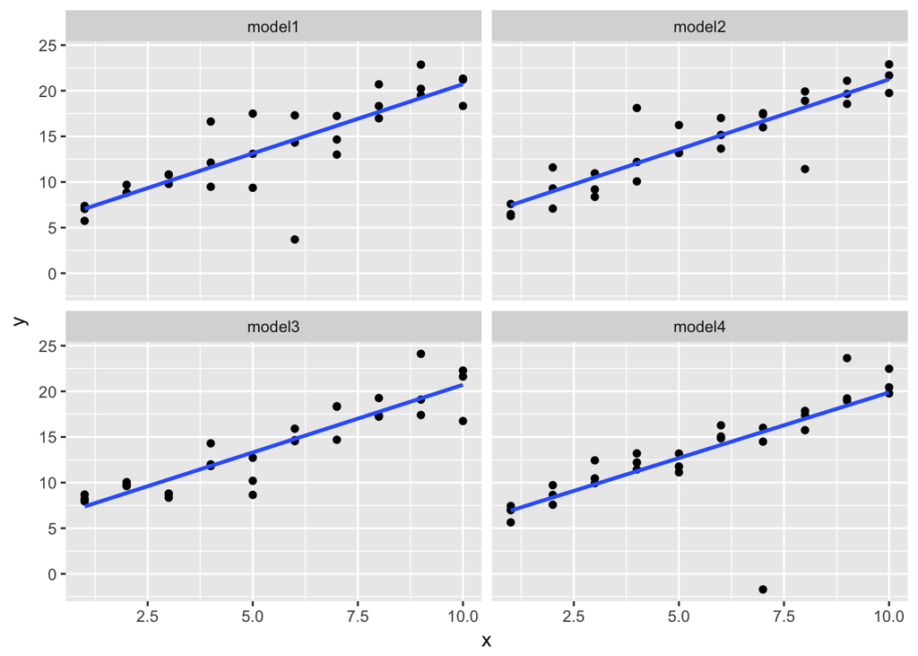

```r
set.seed(20180315)
sim1a <- tibble(
    x = rep(rep(1:10, each = 3), 4),
    y = x * 1.5 + 6 + rt(length(x), df = 2),
    model = rep(c("model1", "model2", "model3", "model4"), each = length(x) / 4)
)

sim1a %>%
  ggplot(aes(x, y)) +
  geom_point() +
  geom_smooth(method = "lm", se = FALSE) +
  facet_wrap(~model)
```

The fitted line is surprsingly stable, but it doesn’t do a good job accounting for values that are far from the fitted line.

### Problem 2

One way to make linear models more robust is to use a different distance measure. For example, instead of root-mean-squared distance, you could use mean-absolute distance:

```
measure_distance <- function(mod, data) {
  diff <- data$y - make_prediction(mod, data)
  mean(abs(diff))
}
```

Use `optim()` to fit this model to the simulated data above and compare it to the linear model.

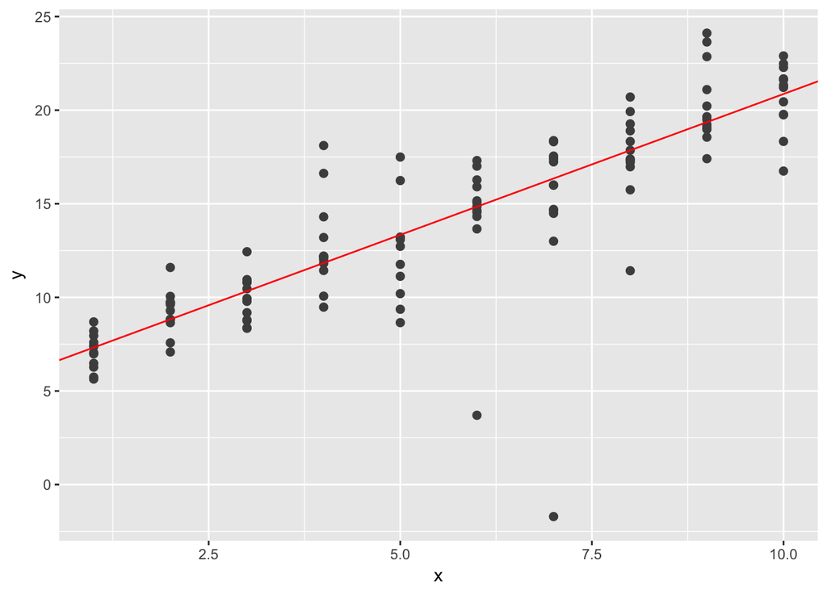

```r
library(modelr)

model1 <- function(a, data) {
  a[1] + data$x * a[2]
}

measure_distance <- function(mod, data) {
  diff <- data$y - model1(mod, data)
  mean(abs(diff))
}

best <- optim(c(0, 0), measure_distance, data = sim1a)

ggplot(sim1a, aes(x, y)) +
  geom_point(size = 2, colour = "grey30") +
  geom_abline(intercept = best$par[1], slope = best$par[2], color = "red")
```

### Problem 3

One challenge with performing numerical optimisation is that it’s only guaranteed to find one local optima. What’s the problem with optimising a three parameter model like this?

```
model1 <- function(a, data) {
  a[1] + data$x * a[2] + a[3]
}
```

## 23.3 Visualizing models

Instead of using `lm()` to fit a straight line, you can use `loess()` to fit a smooth curve. Repeat the process of model fitting, grid generation, predictions, and visualisation on sim1 using `loess()` instead of `lm()`. How does the result compare to `geom_smooth()`?

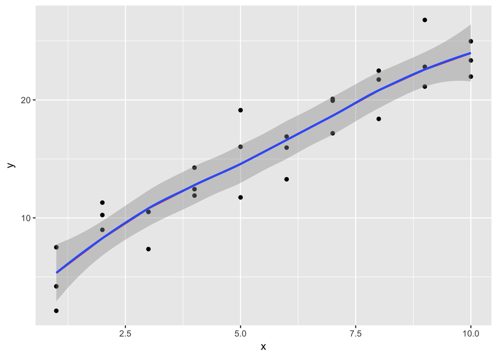

```r
sim1_loess <- loess(y ~ x, data = sim1)

sim1_loess <- loess(y ~ x^2, data = sim1)

grid <- sim1 %>%
  data_grid(x) %>%
  add_predictions(sim1_loess)

ggplot(sim1, aes(x)) +
  geom_point(aes(y = y)) +
  geom_line(aes(y = pred), data = grid, colour = "red", size = 1) +
  geom_smooth(aes(y = y))
```

The result is identical to `geom_smooth()` without the standard error shading.

### Problem 3

`add_predictions()` is paired with `gather_predictions()` and `spread_predictions()`. How do these three functions differ?

`gather_predictions()` and `spread_predictions()` work with multiple models and `add_predictions()` only works with one model. `gather_predictions()` adds each prediction as a new row with a column for model name and a column for prediction. `spread_predictions()` adds a new column for the predictions from each model.

### Problem 3

What does `geom_ref_line()` do? What package does it come from? Why is displaying a reference line in plots showing residuals useful and important?

`geom_ref_line()`, from `library(modelr)`, can add horizontal and vertical reference lines. This could be useful for visually partitioning points or comparing the slope or slopes from models against levels lines.

### Problem 4

Why might you want to look at a frequency polygon of absolute residuals? What are the pros and cons compared to looking at the raw residuals?

A frequency polygon of absolute residuals is useful for exploring the magnitudes of errors from a model. A problem is that is can obscure real differences between residuals from above the fitted model and residuals below the fitted model.

## 23.4 Formulas and model families

What happens if you repeat the analysis of `sim2` using a model without an intercept. What happens to the model equation? What happens to the predictions?

```r
mod2 <- lm(y ~ x - 1, data = sim2)

model_matrix(y ~ x, data = sim2)
```

```
## # A tibble: 40 x 4
##    `(Intercept)`    xb    xc    xd
##            <dbl> <dbl> <dbl> <dbl>
##  1          1.00     0     0     0
##  2          1.00     0     0     0
##  3          1.00     0     0     0
##  4          1.00     0     0     0
##  5          1.00     0     0     0
##  6          1.00     0     0     0
##  7          1.00     0     0     0
##  8          1.00     0     0     0
##  9          1.00     0     0     0
## 10          1.00     0     0     0
## # ... with 30 more rows
```

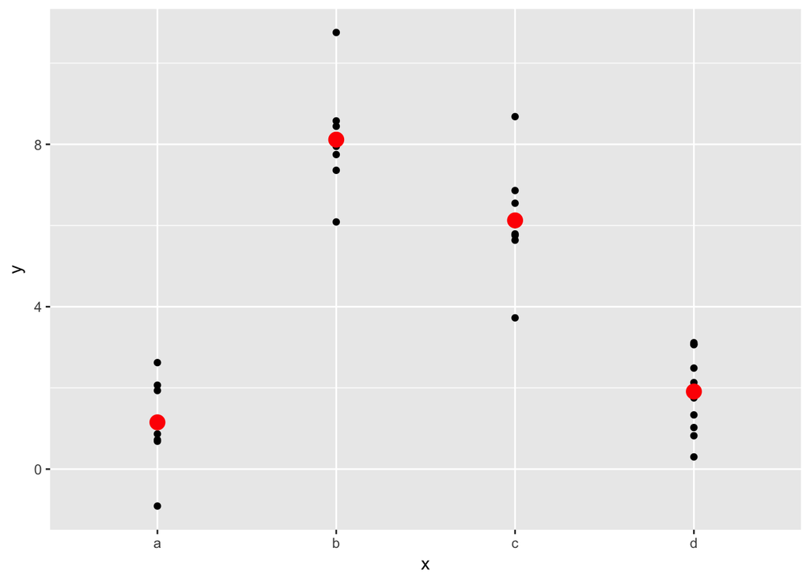

```r
grid <- sim2 %>%
  data_grid(x) %>%
  add_predictions(mod2)

ggplot(sim2, aes(x)) +
  geom_point(aes(y = y)) +
  geom_point(data = grid, aes(y = pred), colour = "red", size = 4)
```

The model equation changes from `y = a_0 + a_1 * xb + a_2 * xc + a_3 * xd` to `y = a_1 * xa + a_2 * xb + a_3 * xc + a_4 * xd`. Basically, the first model replaces one level of the equation with the y-intercept. The second model has no intercept and all four levels of the discrete variable. The predictions don’t change.